# Tutorial: bulk RNA-seq deconvolution using BayesPrism

Sophia Zhao

2023-12-13

Due to the computational ability, the code up to runing BayesPrism will not be run through. (We run excute_PBMC.R file in Compute Canada.) Here we use PBMC data, the procedure of pancreas is the same, just changing the data input.

Load the BayesPrism package

```r
# install.packages("snowfall")
# install.packages("NMF")
# install.packages("gplots")
# install.packages("scran")
# install.packages("BiocParallel")
# install.packages("devtools")
library(snowfall)
library(NMF)
library(gplots)
library(scran)
library(BiocParallel)
library(devtools)
# install_github("Danko-Lab/BayesPrism/BayesPrism")
suppressWarnings(library(BayesPrism))
```

## Load the data

`bk.dat`: The sample-by-gene raw count matrix of bulk RNA-seq expression. `rownames` are bulk sample IDs, while `colnames` are gene names/IDs.

`sc.dat`: The cell-by-gene raw count matrix of bulk RNA-seq expression. `rownames` are bulk cell IDs, while `colnames` are gene names/IDs.

`cell.type.labels` is a character vector of the same length as `nrow(sc.dat)` to denote the cell type of each cell in the reference.

`cell.state.labels` is a character vector of the same length as `nrow(sc.dat)` to denote the cell state of each cell in the reference. In our example, cell states of malignant cells were obtained by sub-clustering the malignant cells from each patient, and cell states of myeloid cells were obtained by clustering myeloid cells from all patients. We define multiple cell states for these two cell types, as they contain substantial heterogeneity while also having sufficient number of cells for sub-clustering.

Please make sure that all cell states contain a reasonable number of cells, e.g. >20 or >50, so that their profile can be represented accurately.

```r
PBMCbulk <- read.table(file = "PBMC_ARCHIVE/Fig2b-WholeBlood_RNAseq.txt", header = TRUE,sep = "\t")
rownames(PBMCbulk) <- PBMCbulk[,1]
PBMCbulk<-PBMCbulk[,-1]

PBMCref <- read.table(file = "PBMC_ARCHIVE/Fig2ab-NSCLC_PBMCs_scRNAseq_refsample.txt", header = TRUE,sep = "\t")
rownames(PBMCref) <- PBMCref[,1]
PBMCref<-PBMCref[,-1]
head(PBMCref[,1:3])
head(PBMCbulk[,1:3])


bk.dat <- t(as.matrix(PBMCbulk,byrow = TRUE,
                      dimnames = list(rownames(PBMCbulk),
                                      colnames(PBMCbulk))))
#head(bk.dat[,1:5])
head(bk.dat[,1:5])
head(PBMCref[,1:5])
sc.dat <- t(as.matrix(PBMCref,byrow = TRUE,
                      dimnames = list(rownames(PBMCref),
                                      colnames(PBMCref))))
head(PBMCref[,1:5])


PBMCref_cell <- colnames(PBMCref)
# Cell types
PBMCcell_types <- c("B.cells", "T.cells.CD4", "T.cells.CD8", "NKT.cells", "NK.cells", "Monocytes")

library(stringr)
# Extract cell type and additional information using stringr
matches <- str_match(PBMCref_cell, paste0("(", paste(PBMCcell_types, collapse = "|"), ")\\.?(.*)"))
cell.type.labels<-matches[, 2]
cell.state.labels<-gsub("\\.", "-", matches[, 1])

sort(table(cell.type.labels))
sort(table(cell.state.labels))
table(cbind.data.frame(cell.state.labels, cell.type.labels))
```

## Filter outlier genes

Gene expressed at high magnitude, such as ribosomal protein genes and mitochondrial genes, may dominate the distribution and bias the inference. These genes are often not informative in distinguishing cell types and can be a source of large spurious variance. As a result, they can be detrimental to deconvolution. We recommend the removal of these genes.

Users may visualize the distribution of outlier genes from scRNA-seq reference. We compute the mean expression and of each gene across all cell types, and their cell type specificity scores.

Visualize and determine outlier genes from scRNA-seq data

Similarly, we may also visualize outlier genes from bulk RNA-seq. We compute the mean expression and of each gene across all cell types. As we do not have cell type level information from bulk data, we compute cell type specificity score from scRNA-seq, same as above.

Visualize outlier genes in bulk RNA-seq

```r
sc.stat <- plot.scRNA.outlier(
      input=sc.dat, #make sure the colnames are gene symbol or ENSMEBL ID
      cell.type.labels=cell.type.labels,
      species="hs", #currently only human(hs) and mouse(mm) annotations are supported
      return.raw=TRUE #return the data used for plotting.
      #pdf.prefix="gbm.sc.stat" specify pdf.prefix if need to output to pdf
)
bk.stat <- plot.bulk.outlier(
      bulk.input=bk.dat,#make sure the colnames are gene symbol or ENSMEBL ID
      sc.input=sc.dat, #make sure the colnames are gene symbol or ENSMEBL ID
      cell.type.labels=cell.type.labels,
      species="hs", #currently only human(hs) and mouse(mm) annotations are supported
      return.raw=TRUE
      #pdf.prefix="gbm.bk.stat" specify pdf.prefix if need to output to pdf
)
sc.dat.filtered <- cleanup.genes (input=sc.dat,
                                  input.type="count.matrix",
                                  species="hs",
                                  gene.group=c( "Rb","Mrp","other_Rb","chrM","MALAT1","chrX","chrY") ,
                                  exp.cells=5)
dim(sc.dat.filtered)

sc.dat.filtered.pc <-  select.gene.type (sc.dat.filtered,
                                         gene.type = "protein_coding")
```

## Construct a prism object.

```r
myPrism <- new.prism(
  reference=sc.dat.filtered.pc,
  mixture=bk.dat,
  input.type="count.matrix",
  cell.type.labels = cell.type.labels,
  cell.state.labels = cell.state.labels,
  key="tumor",
  outlier.cut=0.01,
  outlier.fraction=0.1,
)
```

## Run BayesPrism

Parameters to control Gibbs sampling and optimization can be specified using gibbs.control and opt.control. Do ?run.prism for details. We recommend the use of default parameters.

```r
bp.res <- run.prism(prism = myPrism, n.cores=50)
```

## Report the summary statistics and Extract results

```r
bp.res
slotNames(bp.res)
```

“prism” is the input prism. “posterior.initial.cellState” is the result of step 2. “posterior.initial.cellType” is the result of step 3. “reference.update” is the updated reference ψ . “posterior.theta_f” is the result of step 4. “control_param” contains the parameters to run BayesPrism.

```r
# extract posterior mean of cell type fraction theta
theta <- get.fraction (bp=bp.res,
                       which.theta="final",
                       state.or.type="type")

head(theta)
# # extract coefficient of variation (CV) of cell type fraction
# theta.cv <- bp.res@posterior.theta_f@theta.cv
#
# head(theta.cv)

saveRDS(theta_PBMC, "PBMC_ARCHIVED/PBMC_theta.rds")
#saveRDS(theta.cv_PBMC, "PBMC_ARCHIVED/PBMC_theta.cv.rds")
```

## Analysis PBMC

recall

```r
B.PBMC<-read.table(file = "PBMC_ARCHIVE/Fig2b-WholeBlood_RNAseq.txt", header = TRUE,sep = "\t")
rownames(B.PBMC)<-B.PBMC[,1]
B.PBMC<-B.PBMC[,-1]

A.PBMC<-read.table(file = "PBMC_ARCHIVE/Fig2ab-NSCLC_PBMCs_scRNAseq_sigmatrix.txt", header = TRUE,sep = "\t")
rownames(A.PBMC)<-A.PBMC[,1]
A.PBMC<-A.PBMC[,-1]

ref.PBMC<-read.table(file = "PBMC_ARCHIVE/Fig2ab-NSCLC_PBMCs_scRNAseq_refsample.txt", header = TRUE,sep = "\t")
rownames(ref.PBMC)<-ref.PBMC[,1]
ref.PBMC<-ref.PBMC[,-1]


cyb_P.PBMC<-read.table(file = "PBMC_ARCHIVE/CIBERSORTx_PBMC_Adjusted.txt", header = TRUE,sep = "\t")
rownames(cyb_P.PBMC)<-cyb_P.PBMC[,1]
cyb_P.PBMC<-cyb_P.PBMC[,-1]

bp_P.PBMC<-readRDS("PBMC_ARCHIVE/PBMC_theta.rds")

true_P.PBMC<-read.table(file = "PBMC_ARCHIVE/ground_truth_whole_blood.txt", header = TRUE,sep = "\t")
rownames(true_P.PBMC)<-true_P.PBMC[,1]
true_P.PBMC<-true_P.PBMC[,-1]


head(A.PBMC[,1:5])
```

```
##         T.cells.CD8 Monocytes T.cells.CD4  NKT.cells B.cells
## A2M.AS1   42.389248  3.034278    8.406227  47.115313       1
## AAK1     171.246018 53.947719  245.690249 189.969058       1
## ABCA1      3.097667 14.269549    1.000000   1.000000       1
## ABCA2     22.847189  2.331345    3.134736  21.462190       1
## ABCA3      1.000000  1.653714    1.000000   8.154662       1
## ABCB1      9.688696  1.000000    1.000000   9.468835       1
```

```r
head(B.PBMC[,1:5])
```

```
##           W070517001156 W070517001157 W070517001159 W070517001160 W070517001161
## 5_8S_rRNA    0.00000000     0.0000000    0.00000000     0.0000000    0.00000000
## 5S_rRNA      0.00000000     0.0000000    0.00000000     0.0000000    0.00000000
## 7SK          0.00000000     0.0000000    0.00000000     0.0000000    0.00000000
## A1BG         1.52458880     1.1982094    2.28110130     2.5109631    1.75268600
## A1BG-AS1     0.21001956     0.2630730    0.41086500     0.5714840    0.13972470
## A1CF         0.00707868     0.1093625    0.02942712     0.0129127    0.02266773
```

```r
head(ref.PBMC[,1:5])
```

```
##               T.cells.CD8 T.cells.CD8.1 T.cells.CD8.2 Monocytes Monocytes.1
## RP11.34P13.7            0             0             0         0           0
## AL627309.1              0             0             0         0           0
## AP006222.2              0             0             0         0           0
## RP4.669L17.10           0             0             0         0           0
## RP5.857K21.3            0             0             0         0           0
## RP11.206L10.3           0             0             0         0           0
```

```r
head(cyb_P.PBMC)
```

```
##               T.cells.CD8 Monocytes T.cells.CD4   NKT.cells     B.cells
## W070517001156 0.118839521 0.6579589   0.1693491 0.000000000 0.004817541
## W070517001157 0.004184556 0.3234366   0.5439695 0.000000000 0.043497089
## W070517001159 0.145141369 0.5309346   0.1475633 0.000000000 0.081384673
## W070517001160 0.115550194 0.3367832   0.4790113 0.000000000 0.021077787
## W070517001161 0.333607289 0.4064591   0.1699074 0.016685922 0.044655632
## W070517001162 0.187335668 0.2216976   0.4626743 0.003556701 0.064522376
##                 NK.cells P.value Correlation      RMSE
## W070517001156 0.04903497       0   0.8509379 0.6848389
## W070517001157 0.08491234       0   0.7996460 0.6005462
## W070517001159 0.09497609       0   0.7811211 0.7164904
## W070517001160 0.04757760       0   0.7696200 0.6384052
## W070517001161 0.02868473       0   0.8422725 0.5403754
## W070517001162 0.06021339       0   0.8414199 0.5870823
```

```r
head(bp_P.PBMC)
```

```
##               T.cells.CD8 Monocytes T.cells.CD4  NKT.cells    B.cells
## W070517001156   0.2524192 0.5926574  0.04736811 0.03900301 0.02247716
## W070517001157   0.2755751 0.4393540  0.15261030 0.02949427 0.04622899
## W070517001159   0.2231153 0.5705307  0.08180345 0.02815088 0.03558478
## W070517001160   0.2995859 0.4512634  0.11205910 0.03428693 0.04088893
## W070517001161   0.2567433 0.4394547  0.18379001 0.02680557 0.04246547
## W070517001162   0.2892440 0.3534543  0.16052388 0.03933052 0.08005699
##                 NK.cells
## W070517001156 0.04607517
## W070517001157 0.05673735
## W070517001159 0.06081484
## W070517001160 0.06191569
## W070517001161 0.05074098
## W070517001162 0.07739033
```

```r
head(true_P.PBMC)
```

```
##               Neutrophils Lymphocytes Monocytes T.cells T.cells.CD8 T.cells.CD4
## W070517001156       0.796       0.105     0.099   0.066       0.015       0.041
## W070517001157       0.660       0.259     0.081   0.193       0.048       0.147
## W070517001159       0.770       0.148     0.082   0.044       0.008       0.035
## W070517001160       0.650       0.244     0.106   0.210       0.032       0.190
## W070517001161       0.537       0.281     0.183   0.223       0.142       0.072
## W070517001162       0.489       0.433     0.078   0.280       0.082       0.193
##               B.cells NK.cells
## W070517001156   0.010    0.021
## W070517001157   0.039    0.031
## W070517001159   0.052    0.058
## W070517001160   0.024    0.025
## W070517001161   0.032    0.070
## W070517001162   0.059    0.100
```

```r
mat.A.PBMC<-as.matrix(A.PBMC)
celltype.PBMC <- colnames(A.PBMC)
celltype.PBMC %in% colnames(true_P.PBMC)
```

```
## [1]  TRUE  TRUE  TRUE FALSE  TRUE  TRUE
```

```r
# [1]  TRUE  TRUE  TRUE FALSE  TRUE  TRUE
# discard "NKT.cells"
mat.A.PBMC <- mat.A.PBMC[,-4]
celltype.PBMC <- celltype.PBMC[-4]


mat.true_P.PBMC<-as.matrix(true_P.PBMC[,celltype.PBMC])
mat.cyb_P.PBMC <-as.matrix(cyb_P.PBMC[,celltype.PBMC])
mat.bp_P.PBMC  <-as.matrix(bp_P.PBMC[,celltype.PBMC])

hat_true_B.PBMC <- mat.A.PBMC %*% t(mat.true_P.PBMC)
hat_cyb_B.PBMC  <- mat.A.PBMC %*% t(mat.cyb_P.PBMC)
hat_bp_B.PBMC   <- mat.A.PBMC %*% t(mat.bp_P.PBMC)

# find pair of samples in real and estimated bulk
sample.PBMC<- intersect(row.names(hat_true_B.PBMC),row.names(B.PBMC))
hat_true_B.PBMC2<-hat_true_B.PBMC[sample.PBMC,]
hat_cyb_B.PBMC2 <-hat_cyb_B.PBMC[sample.PBMC,]
hat_pb_B.PBMC2  <-hat_bp_B.PBMC[sample.PBMC,]
```

```r
library(ggplot2)
library(RColorBrewer)
library(gridExtra)
# library(knitr)

# 5.1 Cell Type Proportions Analysis
celleval<-function(hat_P,hat2_P,P){ # hat1 for CybersortX hat2 for BayesPrism
  # cell-type-level analysis
  MSE_cell<-apply((P-hat_P)^2,2,mean)
  r_cell  <-apply((hat_P-apply(hat_P,2,mean))*(P-apply(P,2,mean)),2,sum)/
    (sqrt(apply((hat_P-apply(hat_P,2,mean))^2,2,sum))*sqrt(apply((P-apply(P,2,mean))^2,2,sum)))
  # sample-level analysis
  MSE_samp<-apply((P-hat_P)^2,1,mean)
  r_samp  <-apply((hat_P-apply(hat_P,1,mean))*(P-apply(P,1,mean)),1,sum)/
    (sqrt(apply((hat_P-apply(hat_P,1,mean))^2,1,sum))*sqrt(apply((P-apply(P,1,mean))^2,1,sum)))
  # overall
  MSE_all<-mean((P-hat_P)^2)
  r_all  <-sum(hat_P-mean(hat_P)*(P-mean(P)))/
    (norm(hat_P-mean(hat_P))*norm(P-mean(P)))
  ##############################################
  # cell-type-level analysis
  MSE_cell2<-apply((P-hat2_P)^2,2,mean)
  r_cell2  <-apply((hat2_P-apply(hat2_P,2,mean))*(P-apply(P,2,mean)),2,sum)/
        (sqrt(apply((hat2_P-apply(hat2_P,2,mean))^2,2,sum))*sqrt(apply((P-apply(P,2,mean))^2,2,sum)))
  # sample-level analysis
  MSE_samp2<-apply((P-hat2_P)^2,1,mean)
  r_samp2  <-apply((hat2_P-apply(hat2_P,1,mean))*(P-apply(P,1,mean)),1,sum)/
        (sqrt(apply((hat2_P-apply(hat2_P,1,mean))^2,1,sum))*sqrt(apply((P-apply(P,1,mean))^2,1,sum)))
  # overall
  MSE_all2<-mean((P-hat2_P)^2)
  r_all2  <-sum(hat2_P-mean(hat2_P)*(P-mean(P)))/
        (norm(hat2_P-mean(hat2_P))*norm(P-mean(P)))

  mlist<-list(cell_level=matrix(rbind(MSE_cell,MSE_cell2,r_cell,r_cell2),nrow=4,byrow=T,
                                dimnames=
                                      list(c("MSE_cell_CybersortX","MSE_cell_BayesPrism","r_Cell_CybersortX","r_Cell_BayesPrism"),
                                           names(MSE_cell))),
              samp_level=matrix(rbind(MSE_samp,MSE_samp2,r_samp,r_samp2),nrow=4,byrow=T,
                                dimnames=
                                      list(c("MSE_samp_CybersortX","MSE_samp_BayesPrism","r_samp_CybersortX","r_samp_BayesPrism"),
                                           names(MSE_samp))),
              all_level=matrix(c(MSE_all,MSE_all2,r_all,r_all2),ncol=2,byrow=T,
                               dimnames=list(c("overall_CybersortX","overall_BayesPrism"),c("MSE_all","r_all"))))
  return(mlist)

}

# 5.2 Bulk Analysis
visualp<-function(hat_P,hat2_P,P){
df <- data.frame(x = c(P),
                 y = c(hat_P),
                 col = rep(colnames(P), each = nrow(P))
)

df2 <- data.frame(x = c(P),
                  y = c(hat2_P),
                  col = rep(colnames(P), each = nrow(P))
)

# Define colors dynamically based on column names
custom_colors <- brewer.pal(9, "Set1")[1:dim(P)[2]]
color_mapping_df <- setNames(custom_colors, as.character(colnames(P)))
color_mapping_df2 <- setNames(custom_colors, as.character(colnames(P)))

# Plot
p1 <- ggplot(df, aes(x = x, y = y, color = as.factor(col))) +
  geom_point(size = 4) +
  scale_color_manual(values = color_mapping_df) +
  labs(color = "Cell", x = "P", y = expression(hat(P))) +  # LaTeX expression for \hat{P}
  geom_abline(intercept = 0, slope = 1, linetype = "dashed", color = "red") +  # Diagonal line
  ggtitle("CybersortX") +
  theme_minimal()

p2 <- ggplot(df2, aes(x = x, y = y, color = as.factor(col))) +
  geom_point(size = 4) +
  scale_color_manual(values = color_mapping_df2) +
  labs(color = "Cell", x = "P", y = expression(hat(P))) +  # LaTeX expression for \hat{P}
  geom_abline(intercept = 0, slope = 1, linetype = "dashed", color = "red") +  # Diagonal line
  ggtitle("BayesPrism") +
  theme_minimal()

# Combine plots side by side
grid.arrange(p1, p2, ncol = 2)
}
```

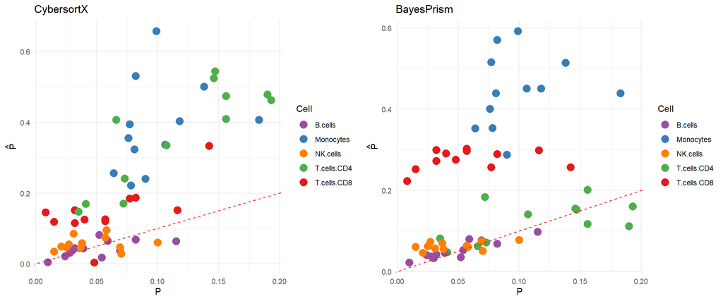

```r
# 5.1
table_P.PBMC<-(celleval(hat2_P=mat.cyb_P.PBMC,hat_P=mat.bp_P.PBMC,P=mat.true_P.PBMC))
table_B.PBMC<-(celleval(hat2_P=t(hat_cyb_B.PBMC2),hat_P=t(hat_pb_B.PBMC2),P=t(hat_true_B.PBMC2)))
# 5.2
visualp(hat_P=mat.cyb_P.PBMC,hat2_P=mat.bp_P.PBMC,P=mat.true_P.PBMC)
```

Tables for fraction estimation (PBMC):

|  | T cells CD8 | Monocytes | T cells CD4 | B cells | NK cells |
| --- | --- | --- | --- | --- | --- |
| MSE_cell_CybersortX | 0.0489232 | 0.0108031 | 0.3527025 | 0.8617802 | 0.1286645 |
| MSE_cell_BayesPrism | 0.0956598 | 0.4292237 | 0.6896613 | 0.0022281 | 0.0715204 |
| r_Cell_CybersortX | 0.2930551 | 0.9484372 | 0.0001611 | 0.0005210 | 0.5519921 |
| r_Cell_BayesPrism | 0.8281485 | 0.0007675 | 0.0009481 | 0.7757775 | 0.8554698 |

|  | MSE_samp_CybersortX | MSE_samp_BayesPrism | r_samp_CybersortX | r_samp_BayesPrism |
| --- | --- | --- | --- | --- |
| W070517001156 | 0.0601781 | 0.0397064 | 0.0286312 | 0.0149859 |
| W070517001157 | 0.0681008 | 0.0288575 | 0.0373642 | 0.0256765 |
| W070517001159 | 0.8431436 | 0.1639830 | 0.0058729 | 0.2570479 |
| W070517001160 | 0.9803383 | 0.9783675 | 0.8933019 | 0.7537479 |
| W070517001161 | 0.0361908 | 0.0183825 | 0.0514986 | 0.0336790 |
| W070517001162 | 0.0442414 | 0.0196201 | 0.0448988 | 0.0293331 |
| W070517102034 | 0.2438570 | 0.9437744 | 0.6307584 | -0.1494216 |
| W070517102035 | 0.9545480 | 0.9480204 | 0.9591039 | 0.7651818 |
| W070517102036 | 0.0574810 | 0.0241669 | 0.0289304 | 0.0399560 |
| W070517102037 | 0.0470502 | 0.0212165 | 0.0294107 | 0.0349161 |
| W070517102038 | 0.4539980 | -0.1385551 | 0.7761115 | 0.7368194 |
| W070517102051 | 0.6104912 | 0.8605750 | 0.9675696 | 0.9396141 |

|  | MSE_all | r_all |
| --- | --- | --- |
| overall_CybersortX | 0.0361489 | 0.0358905 |
| overall_BayesPrism | 5.7225018 | 8.0941073 |

Tables for bulk estimation (PBMC):

|  | MSE_samp_CybersortX | MSE_samp_BayesPrism | r_samp_CybersortX | r_samp_BayesPrism |
| --- | --- | --- | --- | --- |
| W070517001156 | 1.319546e+05 | 6.685077e+04 | 4.939735e+04 | 2.341469e+04 |
| W070517001157 | 1.656799e+05 | 3.379625e+04 | 2.583211e+04 | 1.506268e+04 |
| W070517001159 | 9.985770e-01 | 9.941452e-01 | 9.766753e-01 | 9.710344e-01 |
| W070517001160 | 9.981295e-01 | 9.984838e-01 | 9.764437e-01 | 9.561642e-01 |
| W070517001161 | 7.177169e+04 | 3.690347e+04 | 1.064546e+05 | 5.915099e+04 |
| W070517001162 | 3.711239e+04 | 2.965028e+04 | 6.117898e+04 | 4.557737e+04 |
| W070517102034 | 9.880961e-01 | 9.922675e-01 | 9.948591e-01 | 9.718925e-01 |
| W070517102035 | 9.881290e-01 | 9.936189e-01 | 9.951285e-01 | 9.673582e-01 |
| W070517102036 | 1.282312e+05 | 4.160056e+04 | 6.122457e+04 | 7.825943e+04 |
| W070517102037 | 1.105148e+05 | 1.449805e+04 | 4.802010e+04 | 7.390563e+04 |
| W070517102038 | 9.709818e-01 | 9.441979e-01 | 9.920839e-01 | 9.950818e-01 |
| W070517102051 | 9.774458e-01 | 9.562618e-01 | 9.910188e-01 | 9.948166e-01 |

|  | MSE_all | r_all |
| --- | --- | --- |
| overall_CybersortX | 7.126782e+04 | 5.506904e+04 |
| overall_BayesPrism | 1.993000e-04 | 2.028000e-04 |

## Analysis pancreas

recall

```r
B.pancreas<-read.table(file = "pancreas_ARCHIVE/pancreas_bulk_v2.txt", header = TRUE,sep = "\t")
rownames(B.pancreas)<-B.pancreas[,1]
B.pancreas<-B.pancreas[,-1]

A.pancreas<-read.table(file = "pancreas_ARCHIVE/pancreas_inferred_phenoclasses.txt", header = TRUE,sep = "\t")
rownames(A.pancreas)<-A.pancreas[,1]
A.pancreas<-A.pancreas[,-1]
dim(A.pancreas)
```

```
## [1] 3484    9
```

```r
ref.pancreas<-read.table(file = "pancreas_ARCHIVE/pancreas_scref_v2.txt", header = TRUE,sep = "\t")
rownames(ref.pancreas)<-ref.pancreas[,1]
ref.pancreas<-ref.pancreas[,-1]


cyb_P.pancreas<-read.table(file = "pancreas_ARCHIVE/CIBERSORTx_pancreas_Adjusted.txt", header = TRUE,sep = "\t")
rownames(cyb_P.pancreas)<-cyb_P.pancreas[,1]
cyb_P.pancreas<-cyb_P.pancreas[,-1]

bp_P.pancreas<-readRDS("pancreas_ARCHIVE/pancreas_theta.rds")[,c("acinar", "alpha", "beta", "delta", "ductal", "endothelial", "epsilon", "gamma", "mast", "PSC")] # bp.posterior.initial.cellType.theta.rds") #

true_P.pancreas<-read.table(file = "pancreas_ARCHIVE/pancreas_truth.txt", header = TRUE,sep = "\t")


head(A.pancreas[,1:5])
```

```
##           delta    alpha     gamma   ductal   acinar
## A2M    1.000000  1.00000   1.00000   1.0000  1.00000
## AAK1  32.378652  1.00000  10.26177   1.0000 46.99380
## AAMDC  1.000000 28.34885   1.00000   1.0000  1.00000
## AAMP  42.114050  1.00000 470.75543 123.6610 31.58781
## AARS   1.294129  1.00000  25.06344   1.0000 70.31229
## AARS2  1.000000 23.76611   1.00000 225.3753  1.00000
```

```r
head(B.pancreas[,1:5])
```

```
##         HP1504101T2D_wholeislet HP1506401_wholeislet HP1504901_wholeislet
## SGIP1                       360                  616                  204
## AZIN2                       388                  344                  434
## CLIC4                      3679                 2753                 4151
## AGBL4                       118                  155                  209
## NECAP2                     1522                 1737                 1562
## SLC45A1                     335                  376                  288
##         HP1508501T2D_wholeislet HP1507101_wholeislet
## SGIP1                       567                  171
## AZIN2                       405                  729
## CLIC4                      5125                 3241
## AGBL4                       137                  289
## NECAP2                     2754                 1870
## SLC45A1                     343                  372
```

```r
head(ref.pancreas[,1:5])
```

```
##         delta alpha delta.1 gamma ductal
## SGIP1       0     0       0    32      0
## AZIN2       0     0       0     0      0
## CLIC4       3     0       3     1      0
## AGBL4       0     0       0     0      0
## NECAP2      0     0       0     0      0
## SLC45A1     0     0       0     0      0
```

```r
head(cyb_P.pancreas)
```

```
##                              delta     alpha    epsilon     ductal      acinar
## HP1504101T2D_wholeislet 0.07654934 0.3675667 0.01880283 0.06367805 0.008911613
## HP1506401_wholeislet    0.05203563 0.1056802 0.01347609 0.09581210 0.141012251
## HP1504901_wholeislet    0.15173730 0.3650398 0.02000021 0.06475438 0.004459076
## HP1508501T2D_wholeislet 0.03568430 0.4075551 0.04985844 0.05232344 0.047314379
## HP1507101_wholeislet    0.04538485 0.3867009 0.02940484 0.05198590 0.000000000
## HP1526901T2D_wholeislet 0.10053169 0.3423803 0.01655922 0.09553154 0.014795950
##                              beta        PSC endothelial      gamma P.value
## HP1504101T2D_wholeislet 0.2667957 0.07865377 0.008306869 0.11073504       0
## HP1506401_wholeislet    0.4104715 0.08443773 0.012453182 0.08462139       0
## HP1504901_wholeislet    0.2666840 0.06153482 0.007859034 0.05793138       0
## HP1508501T2D_wholeislet 0.1133799 0.11797416 0.027048941 0.14886132       0
## HP1507101_wholeislet    0.2781141 0.08446318 0.009960608 0.11398563       0
## HP1526901T2D_wholeislet 0.2636698 0.10965806 0.000000000 0.05687349       0
##                         Correlation      RMSE
## HP1504101T2D_wholeislet   0.9931849 0.4253511
## HP1506401_wholeislet      0.9494895 0.6453891
## HP1504901_wholeislet      0.9899945 0.4307863
## HP1508501T2D_wholeislet   0.9925711 0.3857492
## HP1507101_wholeislet      0.9872970 0.4075610
## HP1526901T2D_wholeislet   0.9911782 0.4661171
```

```r
head(bp_P.pancreas)
```

```
##                             acinar     alpha       beta     delta     ductal
## HP1504101T2D_wholeislet 0.05820773 0.1847311 0.11484248 0.1993076 0.04984483
## HP1506401_wholeislet    0.14195936 0.1599755 0.11558871 0.1782265 0.05547166
## HP1504901_wholeislet    0.05469402 0.1801246 0.12512277 0.2122814 0.04781373
## HP1508501T2D_wholeislet 0.08473614 0.1749805 0.09593106 0.1645440 0.06918577
## HP1507101_wholeislet    0.04930766 0.2070771 0.12111327 0.1900756 0.04697244
## HP1526901T2D_wholeislet 0.07297253 0.1629715 0.10978745 0.1906591 0.06563101
##                         endothelial   epsilon      gamma       mast       PSC
## HP1504101T2D_wholeislet 0.010601583 0.1557329 0.08926066 0.01399874 0.1234724
## HP1506401_wholeislet    0.010090420 0.1420658 0.07418562 0.01412024 0.1083162
## HP1504901_wholeislet    0.010938637 0.1491804 0.08090770 0.01466405 0.1242727
## HP1508501T2D_wholeislet 0.014247222 0.1610795 0.08277477 0.01642424 0.1360968
## HP1507101_wholeislet    0.009904531 0.1564693 0.07766488 0.01411594 0.1272993
## HP1526901T2D_wholeislet 0.013117804 0.1475990 0.07740110 0.01525459 0.1446059
```

```r
head(true_P.pancreas)
```

```
##          acinar     alpha       beta       delta     ductal endothelial
## H3   0.35555556 0.1155556 0.14222222 0.008888889 0.29777778 0.000000000
## H4   0.01522843 0.6903553 0.17258883 0.035532995 0.04060914 0.005076142
## H6   0.01442308 0.4423077 0.16826923 0.057692308 0.06730769 0.038461538
## T2D1 0.03265306 0.5755102 0.04081633 0.036734694 0.01224490 0.004081633
## T2D2 0.10526316 0.4473684 0.05263158 0.022556391 0.28571429 0.003759398
## T2D3 0.08695652 0.3152174 0.03985507 0.018115942 0.45289855 0.003623188
##          epsilon      gamma        mast         PSC
## H3   0.004444444 0.06666667 0.000000000 0.008888889
## H4   0.000000000 0.01015228 0.000000000 0.030456853
## H6   0.014423077 0.14903846 0.000000000 0.048076923
## T2D1 0.004081633 0.28571429 0.000000000 0.008163265
## T2D2 0.000000000 0.03007519 0.007518797 0.045112782
## T2D3 0.000000000 0.03623188 0.000000000 0.047101449
```

```r
mat.A.pancreas<-as.matrix(A.pancreas)
celltype.pancreas <- colnames(A.pancreas)
celltype.pancreas %in% colnames(true_P.pancreas)
```

```
## [1] TRUE TRUE TRUE TRUE TRUE TRUE TRUE TRUE TRUE
```

```r
# [1] TRUE TRUE TRUE TRUE TRUE TRUE TRUE TRUE TRUE
celltype.pancreas %in% colnames(cyb_P.pancreas)
```

```
## [1]  TRUE  TRUE  TRUE  TRUE  TRUE  TRUE  TRUE  TRUE FALSE
```

```r
# [1]  TRUE  TRUE  TRUE  TRUE  TRUE  TRUE  TRUE  TRUE FALSE
celltype.pancreas %in% colnames(bp_P.pancreas)
```

```
## [1] TRUE TRUE TRUE TRUE TRUE TRUE TRUE TRUE TRUE
```

```r
# [1] TRUE TRUE TRUE TRUE TRUE TRUE TRUE TRUE TRUE
# discard "mast" (cyb_P)
mat.A.pancreas <- mat.A.pancreas[,-9]
celltype.pancreas <- celltype.pancreas[-9]


mat.true_P.pancreas<-as.matrix(true_P.pancreas[,celltype.pancreas])
mat.cyb_P.pancreas <-as.matrix(cyb_P.pancreas[,celltype.pancreas])
mat.bp_P.pancreas  <-as.matrix(bp_P.pancreas[,celltype.pancreas])

hat_true_B.pancreas <- mat.A.pancreas %*% t(mat.true_P.pancreas)
hat_cyb_B.pancreas  <- mat.A.pancreas %*% t(mat.cyb_P.pancreas)
hat_bp_B.pancreas   <- mat.A.pancreas %*% t(mat.bp_P.pancreas)

# find pair of samples in real and estimated bulk
sample.pancreas<- intersect(row.names(hat_true_B.pancreas),row.names(B.pancreas))
hat_true_B.pancreas2<-hat_true_B.pancreas[sample.pancreas,]
hat_cyb_B.pancreas2 <-hat_cyb_B.pancreas[sample.pancreas,]
hat_pb_B.pancreas2  <-hat_bp_B.pancreas[sample.pancreas,]
```

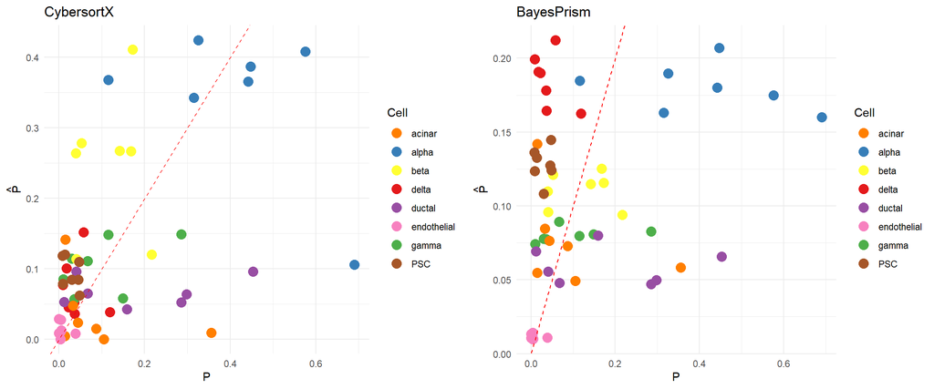

```r
# 5.1
table_P.pancreas<-(celleval(hat2_P=mat.cyb_P.pancreas,hat_P=mat.bp_P.pancreas,P=mat.true_P.pancreas))
table_B.pancreas<-(celleval(hat2_P=t(hat_cyb_B.pancreas2),hat_P=t(hat_pb_B.pancreas2),P=t(hat_true_B.pancreas2)))
# 5.2
visualp(hat_P=mat.cyb_P.pancreas,hat2_P=mat.bp_P.pancreas,P=mat.true_P.pancreas)
```

Tables for fraction estimation (pancreas):

|  | delta | alpha | gamma | ductal | acinar | beta | PSC | endothelial |
| --- | --- | --- | --- | --- | --- | --- | --- | --- |
| MSE_cell_CybersortX | 0.0223751 | 0.0039217 | -0.3504644 | 0.8275831 | 0.0878031 | 0.0648132 | 0.4883967 | 0.6504096 |
| MSE_cell_BayesPrism | 0.0079501 | 0.0061516 | -0.0591843 | 0.4869869 | 0.0397966 | 0.0364939 | 0.0624887 | 0.0478234 |
| r_Cell_CybersortX | 0.0161686 | 0.0218611 | 0.2385266 | 0.6906455 | 0.0048048 | 0.0282010 | 0.5723815 | 0.5810399 |
| r_Cell_BayesPrism | 0.0102612 | 0.0052469 | -0.2649209 | 0.3779061 | 0.0001860 | 0.0003521 | 0.8724120 | 0.9039611 |

|  | MSE_samp_CybersortX | MSE_samp_BayesPrism | r_samp_CybersortX | r_samp_BayesPrism |
| --- | --- | --- | --- | --- |
| H3 | 0.0256791 | 0.1589608 | 0.4808062 | 0.0243618 |
| H4 | 0.0331811 | 0.0134633 | 0.9390541 | 0.0042664 |
| H6 | -0.3412411 | 0.0042530 | 0.0199598 | 0.3529117 |
| T2D1 | -0.0886969 | 0.4817391 | 0.0161727 | 0.0073134 |
| T2D2 | 0.0414228 | 0.8689000 | 0.3474176 | 0.0066053 |
| T2D3 | 0.0532611 | 0.0304258 | 0.5883135 | 0.5964767 |
| T2D4 | 0.4289909 | 0.0083264 | 0.0274130 | 0.7611620 |

|  | MSE_all | r_all |
| --- | --- | --- |
| overall_CybersortX | 0.0236682 | 0.0208802 |
| overall_BayesPrism | 4.3794409 | 2.0879726 |

Tables for bulk estimation (pancreas):

|  | MSE_samp_CybersortX | MSE_samp_BayesPrism | r_samp_CybersortX | r_samp_BayesPrism |
| --- | --- | --- | --- | --- |
| H3 | 4.840579e+05 | 4.903743e-01 | 7.871882e-01 | 1.698733e+05 |
| H4 | 6.553671e+05 | 2.506696e+05 | 9.784685e-01 | 6.396799e-01 |
| H6 | 4.577488e-01 | 4.974920e+04 | 3.081751e+05 | 8.104825e-01 |
| T2D1 | 3.783529e-01 | 7.943034e-01 | 1.400007e+05 | 8.470927e+04 |
| T2D2 | 8.746864e+05 | 9.643570e-01 | 7.232645e-01 | 6.732727e+04 |
| T2D3 | 9.957440e+05 | 5.571523e+05 | 8.851967e-01 | 9.173045e-01 |
| T2D4 | 5.841716e-01 | 1.435953e+05 | 2.775806e+05 | 9.449658e-01 |

|  | MSE_all | r_all |
| --- | --- | --- |
| overall_CybersortX | 4.052902e+05 | 3.173796e+05 |
| overall_BayesPrism | 8.010000e-05 | 4.930000e-05 |